# Part II - Business Investments

## Investigation Overview

> Imagine there is a business you would like to provide financial support for. According to them, all you need to do it take a “little bit of time” to invest “a little bit of money” into their loan. You would like to believe that their business will be successful; despite this, it is important to remain realistic. Statistically, will the process of investing actually be as painless as they make it out to be?

## Dataset Overview and Executive Summary

> This dataset contains loan information collected by Prosper and made available through Udacity. More in depth information about it can be found here: https://docs.google.com/spreadsheets/d/1gDyi_L4UvIrLTEC6Wri5nbaMmkGmLQBk-Yx3z0XDEtI/edit?gid=0#gid=0

> The key insights I will be discussing are centered around business loans, their investor information, and the amount of time that the loan ultimately took to be paid off.

```python
# import all packages and set plots to be embedded inline
import numpy as np
import pandas as pd
import matplotlib.pyplot as plt
import seaborn as sns

# suppress warnings from final output
import warnings
warnings.simplefilter("ignore")
```

```python
# load in the dataset into a pandas dataframe
df = pd.read_csv("./loan_dataset_final.csv")
df_concluded = df[(df['LoanStatus'] == 'Completed') | (df['LoanStatus'] == 'Chargedoff')]
df_completed = df[(df['LoanStatus'] == 'Completed')]
df_bus_comp = df_completed[(df_completed['LoanCategory'] == 'Business')]
df_bus_con = df_concluded[(df_concluded['LoanCategory'] == 'Business')]
```

## Visualization 1

> To start off, business loans have the greatest distribution of investors compared to loans taken out for other purposes.

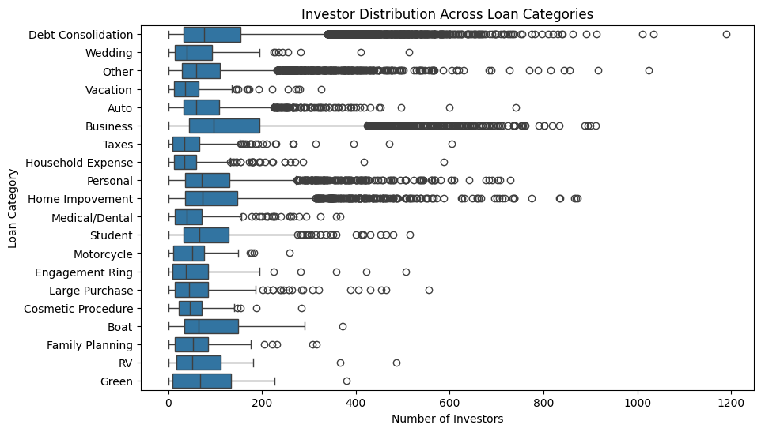

```python
#Creating a bivariate boxplot of Investors to LoanCategory
plt.figure(figsize = [10,6])
sns.boxplot(data=df_concluded, x='Investors', y='LoanCategory');
plt.xlabel('Number of Investors');
plt.ylabel('Loan Category');
plt.title('Investor Distribution Across Loan Categories');
```

> This could be due to a variety of different factors, from the financial stability of the borrower to how successful their business has already been.

## Visualization 2

> It is easy to assume that loans with more investors behind them are more likely to proceed without difficulty.

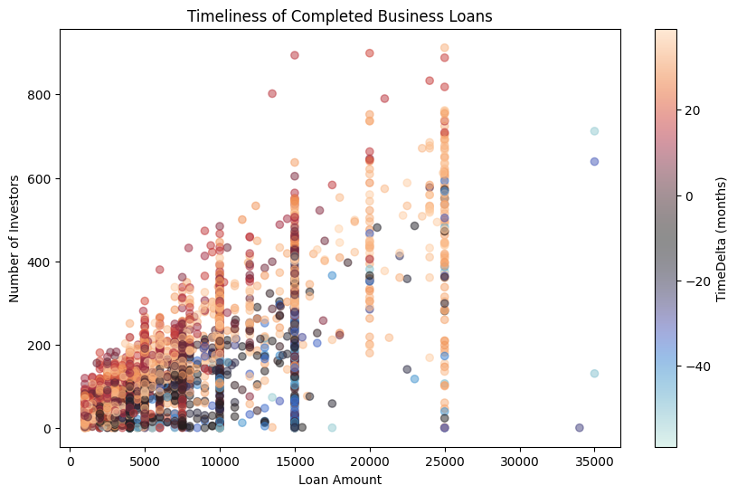

```python
#Making a multivariate scatterplot with color encodings
plt.figure(figsize = [10,6])
plt.scatter(data=df_bus_comp, x='LoanOriginalAmount', y='Investors', c='TimeDelta', cmap='icefire', alpha=1/2);
plt.xlabel('Loan Amount');
plt.ylabel('Number of Investors');
plt.colorbar(label='TimeDelta (months)');
plt.title('Timeliness of Completed Business Loans');
```

> However, looking at the actual amount of time taken on completed loans shows that loans with more investors supporting them are often the ones that go beyond their term.

## Visualization 3

> It would also be inaccurate to assume that loans taken out by those with higher incomes are completely free of issue.

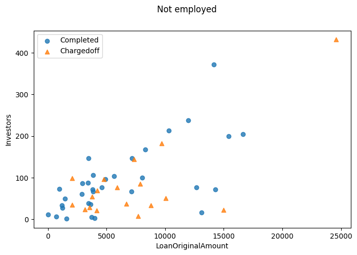

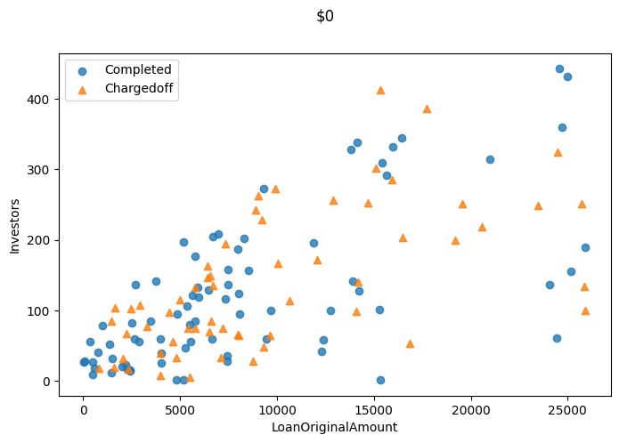

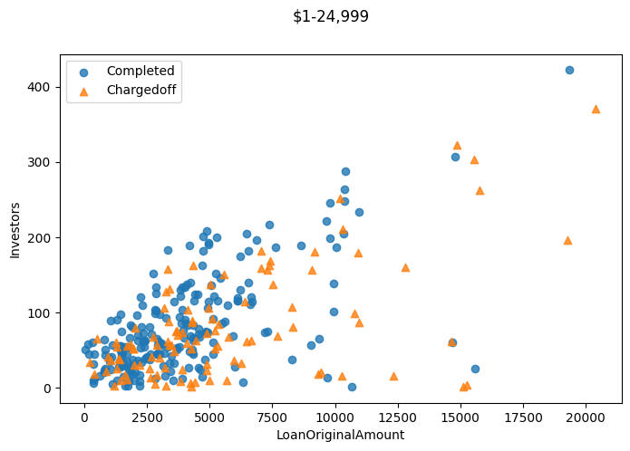

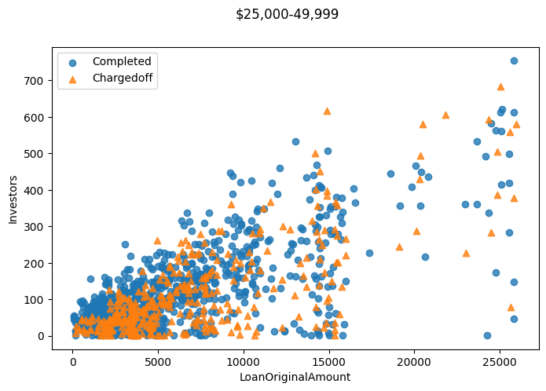

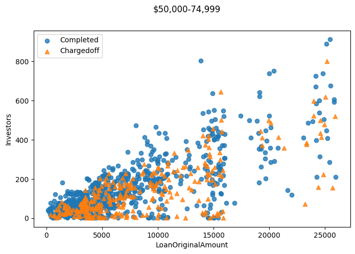

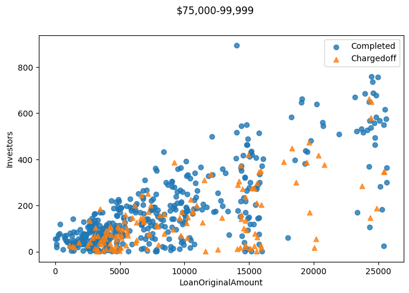

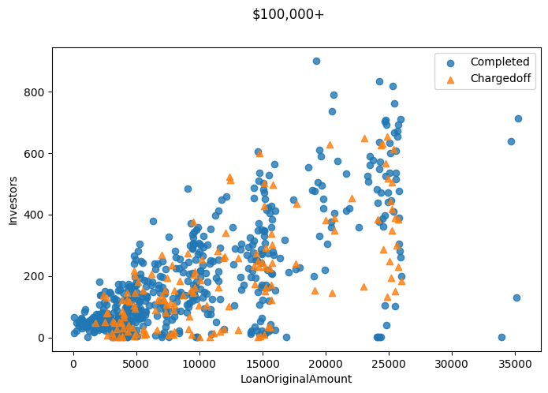

```python
#Separating the data by range of income
IncomeIndex = ['Not employed', '$0', '$1-24,999', '$25,000-49,999',
               '$50,000-74,999', '$75,000-99,999', '$100,000+']

for group in IncomeIndex:
    #Selecting the subset of concluded loans
    group_data = df_bus_con[(df_bus_con['IncomeRange'] == group)]
    #Creating encodings for completed or charged off loan statuses
    ttype_markers = [['Completed', 'o'],['Chargedoff', '^']]
    plt.figure(figsize = [8,5])
    for ttype, marker in ttype_markers:
        plot_data = group_data.loc[group_data['LoanStatus']==ttype]
        #Creating the plot within these subsets for Loan Amount versus Investors
        sns.regplot(data=plot_data, x='LoanOriginalAmount', y='Investors', fit_reg=False, marker=marker, x_jitter=1000);


    #Setting the specific title for each subplot
    plt.suptitle(group, va='top')
    #Ensuring that each have a key to distinguish the resulting loan status
    plt.legend(['Completed', 'Chargedoff'])
```

## Visualization 4

> At the end of this investigation, the key takeaway is that there will always be some amount of risk associated with supporting a business. This is not to say that one should avoid investing their money or time into something they care about. Instead, it can serve as a reminder to really stop and consider the trajectory of your financial involvement. While it might seem simple at first to provide support, it very likely may end up turning into a process that spans years.

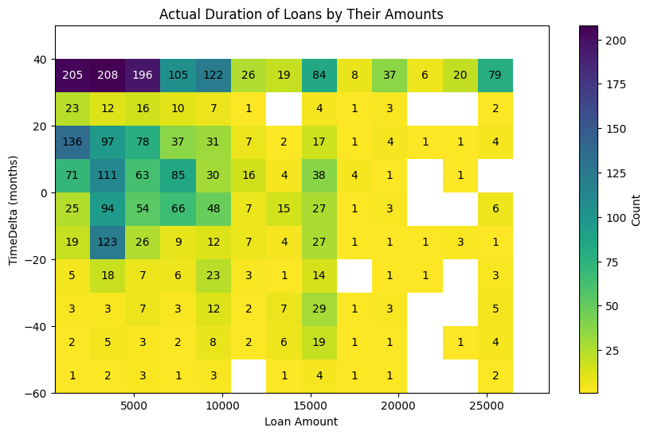

```python
#Creating a bivariate heatmap comparing LoanAmount and TimeDelta
bins_x = np.arange(500, 30000, 2000)
bins_y = np.arange(-60, 60, 10)

plt.figure(figsize = [10,6])
h2d = plt.hist2d(data=df_bus_comp, x='LoanOriginalAmount', y='TimeDelta', cmap='viridis_r', cmin=0.3, bins=[bins_x,bins_y]);

counts = h2d[0]

# Add text annotation on each cell
# Loop through the cell counts and add text annotations for each
for i in range(counts.shape[0]):
    for j in range(counts.shape[1]):
        c = counts[i,j]
        if c >= 195: # increase visibility on darker cells
            plt.text(bins_x[i]+1000, bins_y[j]+5, int(c),
                     ha = 'center', va = 'center', color = 'white')
        elif c > 0:
            plt.text(bins_x[i]+1000, bins_y[j]+5, int(c),
                     ha = 'center', va = 'center', color = 'black')


plt.colorbar(label='Count');
plt.xlabel('Loan Amount');
plt.ylabel('TimeDelta (months)');
plt.title('Actual Duration of Loans by Their Amounts');
```

### Submission

If you are using classroom workspace, you can choose from the following two ways of submission:

1. **Submit from the workspace**. Make sure you have removed the example project from the /home/workspace directory. You must submit the following files:
   - Part_I_notebook.ipynb
   - Part_I_notebook.html or pdf
   - Part_II_notebook.ipynb
   - Part_II_notebook.html or pdf
2. **Submit a zip file on the last page of this project lesson**. In this case, open the Jupyter terminal and run the command below to generate a ZIP file.

```
zip -r my_project.zip .
```

The command abobve will ZIP every file present in your /home/workspace directory. Next, you can download the zip to your local, and follow the instructions on the last page of this project lesson.